# SNA Project: Vegetables and Nutrients Network

In this project, I chose to analyze the the correlation between various vegetables and health benefits. [http://www.nutrition-and-you.com](http://www.nutrition-and-you.com/vegetable-nutrition.html) provides a list of vegetables and descriptions of their health benefits. In this project, we use the information and network analysis to analyze the correlation between vegetables and corresponding health benefits. The basic workflow is as follows:

1. Parse the informatin from the website.
2. Use text mining to extract the key benefit claims.
3. Perform network analysis on the vegetables and their corresponding benefits.

This report is composed using [RMarkdown](http://rmarkdown.rstudio.com/). All the R/RMD codes and dataset for this SNA project can be found on Github: https://github.com/lifan0127/SNA_CourseProject.

*If you are not familiar with RMarkdown style or programming, you can safely skip all the code chunks (shaded sections) and focus on the results and discussion only.*

```r
library(tm)
library(knitr)
library(stringr)
library(RWeka)
library(reshape2)
library(ggplot2)
library(gridExtra)
library(igraph)
library(dplyr)  # version 0.3 required

# Load "vegetables" data frame from vegetable.RData
load("data/vegetables.RData")
```

### Parse the informatin from the website

The data was parsed from the website using the RCurl and XML packages. The script can be found in the [Github reposity](https://github.com/lifan0127/SNA_CourseProject) associated with this project. The basic steps includes:

1. Parse vegetable names, images and links from http://www.nutrition-and-you.com/vegetable-nutrition.html.
2. Following the links, parse the health benefits for each vegetable.
3. Manual check to confirm consistency.

A sample of the data (first 5 vegetables) is shown below:

```r
kable(vegetables[1:5, c("img", "Name", "Link")])
```

| img | Name | Link |
| --- | --- | --- |
|  | Artichoke | http://www.nutrition-and-you.com/artichoke.html |
|  | Arugula | http://www.nutrition-and-you.com/arugula.html |
|  | Asparagus | http://www.nutrition-and-you.com/asparagus.html |
|  | Bamboo_shoots | http://www.nutrition-and-you.com/bamboo-shoots.html |
|  | Basella_(Malabar_spinach) | http://www.nutrition-and-you.com/basella.html |

### Define Nutrient Terms via Text Mining

The first task is to determine the most important nutrient terms asssociated with vegetables. Herein we use the frequencies of terms appearing in the description as the measure. First, we computed the frequency distribution of all term, 2-gram, 3-gram and 4-grams using the *tm* and *RWeka* packages in R.

```r
corpus.preprocess <- function(corpus){
  # Helper function to preprocess corpus
  processed.corpus <- corpus %>%
    tm_map(content_transformer(tolower)) %>%
    tm_map(removeNumbers) %>%
    tm_map(removePunctuation) %>%
    tm_map(removeWords, stopwords("english")) %>%
    tm_map(stripWhitespace)
  return(processed.corpus)
}

corpus <- VCorpus(DirSource("text")) %>% corpus.preprocess()

dtm <- DocumentTermMatrix(corpus)

twogramTokenizer <- function(x) NGramTokenizer(x, Weka_control(min = 2, max = 2))
dtm.2g <- DocumentTermMatrix(corpus, control=list(tokenize = twogramTokenizer))

threegramTokenizer <- function(x) NGramTokenizer(x, Weka_control(min = 3, max = 3))
dtm.3g <- DocumentTermMatrix(corpus, control=list(tokenize = threegramTokenizer))

fourgramTokenizer <- function(x) NGramTokenizer(x, Weka_control(min = 4, max = 4))
dtm.4g <- DocumentTermMatrix(corpus, control=list(tokenize = fourgramTokenizer))
```

Below we plot the top 20 most frequnt terms and [n-grams](http://en.wikipedia.org/wiki/N-gram) (contiguous sequence of n words). We limited our analysis to n=2~4 as it becomes unlikely to have concepts represented by more than 4 words.

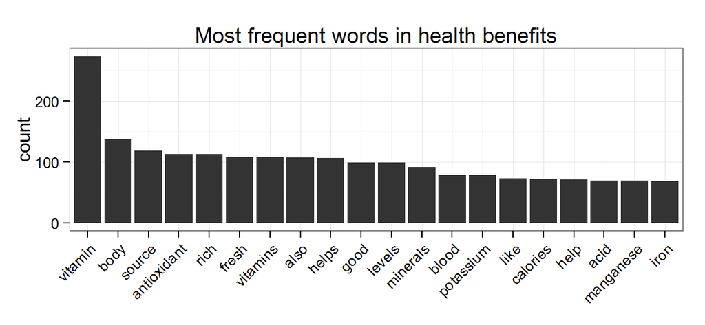

```r
most.freq <- function(dtm, n=20){
  # Helper function to find the most frequent n words
  freq <- colSums(as.matrix(dtm))
  result <- freq[order(freq, decreasing=TRUE)][1:n]
  return(data_frame(term=names(result), count=result))
}

ggplot(most.freq(dtm, 20), aes(x=reorder(term, -count), y=count)) +
  geom_bar(stat="identity") +
  theme_bw() +
  theme(axis.title.x = element_blank(),
           axis.text.x  = element_text(angle=45, hjust=1)) +
  ggtitle("Most frequent words in health benefits")
```

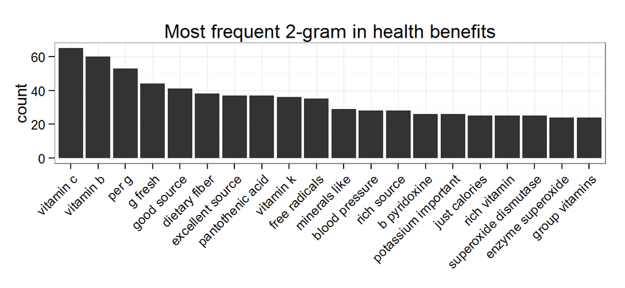

```r
ggplot(most.freq(dtm.2g, 20), aes(x=reorder(term, -count), y=count)) +
  geom_bar(stat="identity") +
  theme_bw() +
  theme(axis.title.x = element_blank(),
           axis.text.x  = element_text(angle=45, hjust=1)) +
  ggtitle("Most frequent 2-gram in health benefits")
```

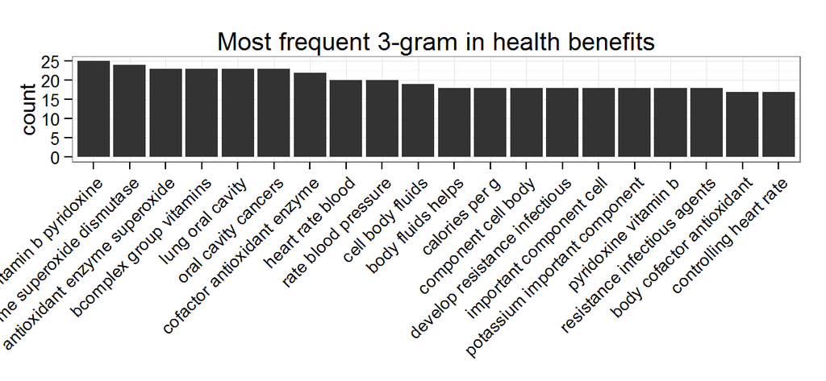

```r
ggplot(most.freq(dtm.3g), aes(x=reorder(term, -count), y=count)) +
  geom_bar(stat="identity") +
  theme_bw() +
  theme(axis.title.x = element_blank(),
           axis.text.x  = element_text(angle=45, hjust=1)) +
  ggtitle("Most frequent 3-gram in health benefits")
```

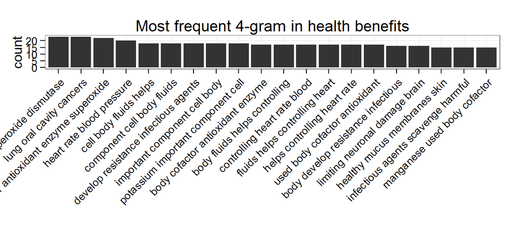

```r
ggplot(most.freq(dtm.4g), aes(x=reorder(term, -count), y=count)) +
  geom_bar(stat="identity") +
  theme_bw() +
  theme(axis.title.x = element_blank(),
           axis.text.x  = element_text(angle=45, hjust=1)) +
  ggtitle("Most frequent 4-gram in health benefits")
```

```r
terms <- c("Antioxidant", "Potassium", "Manganese", "Iron", "Copper", "Calcium",
           "Niacin", "Carotenes", "Carotenoid", "Flavonoid", "Sodium", "Magnesium",
           "Vitamin C", "Vitamin B", "Dietary Fiber", "Pantothenic Acid",
           "Vitamin K")

alias <- c(Pyridoxine="Vitamin B", Folates="Vitamin B", "Folic Acid"="Vitamin B", Thiamin="Vitamin B", riboflavin="Vitamin B", "Superoxide dismutase"="Antioxidant", VitaminC="Vitamin C", Zeaxanthin="Carotenoid", Lutein="Carotenoid")

# Creat a new dtm containing all 1-4 grams and subset with terms/alias
aliasTrans <- content_transformer(function(x, alias) {
    for(i in 1:length(alias))
      x <- gsub(tolower(names(alias[i])), tolower(alias[i]), x)
    return(x)
  })
new.corpus <- tm_map(corpus, aliasTrans, alias)
tokenizer <- function(x) NGramTokenizer(x, Weka_control(min = 1, max = 4))
dtm.all <- DocumentTermMatrix(new.corpus, control=list(tokenize = tokenizer))
dtm.all <- dtm.all[, tolower(terms)]
```

Afterwards, we filtered the document-term matrix using the terms and alias and the resulting new matrix contains 17 nutrient terms and has a parsity of 33%.

### Construct Vegetable-Nutrient Pairs and Network

Thereafter, we used the term list to build vegetable-nutrient pairs. Each pair, established if a nutrient was mentioned in the health benefit description of a vegetable, represents that the vegetable is a good/significant source of the particular nutrient. The vegetable-nutrient pairs collectively constitute a directed graph structure that was used for the subsequent network analysis.

```r
vegetable.nutrient <- as.data.frame(as.matrix(dtm.all)) %>%
  mutate(Vegetable=vegetables$Name) %>%
  melt(id="Vegetable", variable.name="Nutrient", value.name="Count") %>%
  filter(Count>0)
```

### Analysis of the Vegetable-Nutrient Network

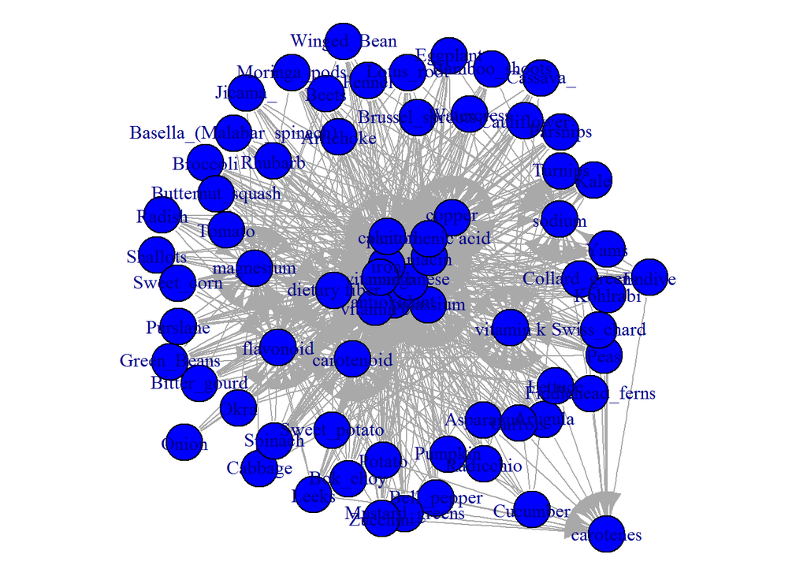

```r
g <- graph.data.frame(vegetable.nutrient)

V(g)$color <- ifelse(V(g)$name %in% tolower(vegetables$Name), "green", "blue")


par(mar=c(0.1, 0.1, 0.1, 0.1))
set.seed(123)
plot(g)
```